# Reglas de Asociación - Dataset online.csv

Mayo de 2019

## Contenido

- Descargar a local el *dataset* *online.csv*
- Analizar la estructura y tipo del *dataset*
- Analizar significado, estructura y tipo de cada columna
- Comandos para ver las primeras filas y las últimas
- Cambiar los nombres de las columnas: *Fecha*, *IDcomprador*, *ProductoComprado*
- Hacer un resumen (`summary`) del *dataset* y analizar detalladamente toda la información que devuelve el comando
- Implementar una función que, usando funciones vectoriales de *R* (`apply`, `tapply`, `sapply` …) devuelva si hay valores `NA` en las columnas del *dataset*. Si as? lo fuera, devolver sus índices y además sustituirlos por el valor \(0\)

## Contenido (II)

- Calcular número de filas del *dataset*
- Calcula en cuántas fechas distintas se han realizado ventas
- Calcula cuántos compradores distintos hay en el *dataset*
- Calcula cuántos productos distintos se han vendido
- Visualiza con distintos gráficos el *dataset*: + Los valores distintos de cada columna con varios tipos de gráficos + Enfrenta unas variables contra otras para buscar patrones y comenta los patrones que puedas detectar

## Contenido (III)

- Usa `split` para construir a partir del *dataset* una lista con nombre *lista.compra.usuarios* en la que cada elemento de la lista es cada comprador junto con todos los productos que ha comprado
- Hacer `summary` de *lista.compra.usuarios*
- Contar cuántos usuarios hay en la *lista.compra.usuarios*
- Detectar y eliminar duplicados en la *lista.compra.usuarios*
- Contar cuántos usuarios hay en la lista después de eliminar duplicados
- Convertir a tipo de datos transacciones. Guardar en *Tlista.compra.usuarios*
- Hacer `inspect` de los dos primeros valores de *Tlista.compra.usuarios*

## Contenido (IV)

- Buscar ayuda de `itemFrequencyPlot` para visualizar las \(20\) transacciones más frecuentes
- Generar las reglas de asociación con \(80\)% de confianza y \(15\)% de soporte
- Ver las reglas generadas y ordenalas por *lift*. Guarda el resultado en una variable nueva
- Elimina todas las reglas redundantes. Calcula el % de reglas redundantes que hab?a. Dibuja las reglas ordenadas y no redundantes usando paquete *arulesViz*. Si son muchas visualiza las \(20\) primeras.
- Aplicar la noci?n de afinidad introducida en clase
- Investigar algún otro paquete *R* relacionado con reglas de asociación. Explicar su uso con un *dataset* y ejemplos

## Descargar a local el *datasetonline.csv*

Cargamos la librería *readr* para usar `read_cs()` e indicamos que no tome la primera fila del *csv* como las columnas de *data frame* mediante `col_names = F`.

También cargamos las librerías *ggplot2* para crear gráficas, *dplyr* para manipular los datos y *arules* para la reglas de asociación.

```r
library(readr)
online <- read_csv("online.csv", col_names = F)
library(ggplot2)
library(dplyr)
library(arules)
```

Podemos visualizar el *dataset* como si fuera una hoja de cálculo con el comando `View(online)`

## Analizar la estructura y tipo del *dataset*

```r
str(online)
```

```
## tibble [22,343 x 3] (S3: spec_tbl_df/tbl_df/tbl/data.frame)
##  $ X1: Date[1:22343], format: "2000-01-01" "2000-01-01" ...
##  $ X2: num [1:22343] 1 1 1 1 1 1 1 1 1 1 ...
##  $ X3: chr [1:22343] "yogurt" "pork" "sandwich bags" "lunch meat" ...
##  - attr(*, "spec")=
##   .. cols(
##   ..   X1 = col_date(format = ""),
##   ..   X2 = col_double(),
##   ..   X3 = col_character()
##   .. )
```

Se observa que *online* es un *data frame* cuyas columnas son vectores de tipo **Date***, **numeric*** y *character*.

## Analizar la estructura y tipo del *dataset* (II)

```r
class(online) # tipo o clase del objeto
```

```
## [1] "spec_tbl_df" "tbl_df"      "tbl"         "data.frame"
```

```r
typeof(online) # tipo que usa R para representar el objeto internamente
```

```
## [1] "list"
```

```r
is.data.frame(online)
```

```
## [1] TRUE
```

```r
is.list(online)
```

```
## [1] TRUE
```

## Analizar significado, estructura y tipo de cada columna

Accedemos a la primera columna mediante `online$X1`

```r
str(online$X1)
```

```
##  Date[1:22343], format: "2000-01-01" "2000-01-01" "2000-01-01" "2000-01-01" "2000-01-01" ...
```

```r
class(online$X1)
```

```
## [1] "Date"
```

```r
typeof(online$X1)
```

```
## [1] "double"
```

Tenemos un vector con 22343 valores de tipo *Date* que *R* representa internamente mediante el tipo *double*

## Analizar significado, estructura y tipo de cada columna (II)

Accedemos a la segunda columna mediante `online$X2`

```r
str(online$X2)
```

```
##  num [1:22343] 1 1 1 1 1 1 1 1 1 1 ...
```

```r
class(online$X2)
```

```
## [1] "numeric"
```

```r
typeof(online$X2)
```

```
## [1] "double"
```

Tenemos un vector con 22343 valores de tipo *numeric* que *R* representa internamente mediante el tipo *double*

## Analizar significado, estructura y tipo de cada columna (III)

Accedemos a la tercera columna mediante `online$X3`

```r
str(online$X3)
```

```
##  chr [1:22343] "yogurt" "pork" "sandwich bags" "lunch meat" "all- purpose" ...
```

```r
class(online$X3)
```

```
## [1] "character"
```

```r
typeof(online$X3)
```

```
## [1] "character"
```

Tenemos un vector con 22343 valores de tipo *character* que *R* representa internamente mediante el tipo *character*

## Comandos para ver las primeras filas y las últimas

```r
head(online, 3) #  muestra las tres primeras filas
```

```
## # A tibble: 3 x 3
##   X1            X2 X3
##   <date>     <dbl> <chr>
## 1 2000-01-01     1 yogurt
## 2 2000-01-01     1 pork
## 3 2000-01-01     1 sandwich bags
```

```r
tail(online, 3) # muestra las tres ?ltimas filas
```

```
## # A tibble: 3 x 3
##   X1            X2 X3
##   <date>     <dbl> <chr>
## 1 2002-02-26  1139 vegetables
## 2 2002-02-26  1139 shampoo
## 3 2002-02-26  1139 vegetables
```

## Cambiar los nombres de las columnas: Fecha, IDcomprador, ProductoComprado

Al no proporcionar nombres a las columnas al importar el *csv*, *R* les asigna un nombre por defecto (**X1**, **X2**, **X3**)

```r
names(online)
```

```
## [1] "X1" "X2" "X3"
```

Podemos indicar otros nombres mediante asignanción:

```r
online <- as.data.frame(online)
names(online) <- c("Fecha", "IDcomprador", "ProductoComprado")
head(online, 2)
```

```
##        Fecha IDcomprador ProductoComprado
## 1 2000-01-01           1           yogurt
## 2 2000-01-01           1             pork
```

## Hacer un resumen del *dataset* y analizar detalladamente toda la información que devuelve el comando

`summary()` devuelve un resumen tras aplicar algunas funciones estadísticas básicas:

```r
summary(online)
```

```
##      Fecha             IDcomprador     ProductoComprado
##  Min.   :2000-01-01   Min.   :   1.0   Length:22343
##  1st Qu.:2000-05-29   1st Qu.: 292.0   Class :character
##  Median :2001-01-30   Median : 582.0   Mode  :character
##  Mean   :2000-12-21   Mean   : 576.4
##  3rd Qu.:2001-06-21   3rd Qu.: 863.0
##  Max.   :2002-02-26   Max.   :1139.0
```

## Hacer un resumen del *dataset* y analizar detalladamente toda la información que devuelve el comando (II)

```r
summary(online$Fecha)
```

```
##         Min.      1st Qu.       Median         Mean      3rd Qu.         Max.
## "2000-01-01" "2000-05-29" "2001-01-30" "2000-12-21" "2001-06-21" "2002-02-26"
```

Observamos que para la columna `online$Fecha`:

- Los datos se encuentran entre *2000-01-01* y *2002-02-26*
- La media es *2000-12-21*
- Las fechas que dejan por debajo (o son iguales) al \(25\%\), \(50\%\) y \(75\%\) de todas las fechas son, respectivamente, *2000-05-29*, *2001-01-30* y *2001-06-21*

## Hacer un resumen del *dataset* y analizar detalladamente toda la información que devuelve el comando (III)

```r
summary(online$IDcomprador)
```

```
##    Min. 1st Qu.  Median    Mean 3rd Qu.    Max.
##     1.0   292.0   582.0   576.4   863.0  1139.0
```

Observamos que para la columna `online$IDcomprador`:

- Los datos se encuentran entre \(1\) y \(1139\)
- La media es \(576.4\)
- Las *ids* que dejan por debajo (o son iguales) al \(25\%\), \(50\%\) y \(75\%\) de todos las *ids* son, respectivamente, \(292\), \(582\) y \(863\)

## Hacer un resumen del *dataset* y analizar detalladamente toda la información que devuelve el comando (IV)

```r
summary(online$ProductoComprado)
```

```
##    Length     Class      Mode
##     22343 character character
```

Observamos que para la columna `online$ProductoComprado`:

- Hay un total de \(22343\) productos
- La clase y modo de almacenamiento de los elementos de la columna es *character*

## Implementar una funci?n que, usando funciones vectoriales de *R*, devuelva si hay valores `NA` en las columnas del *dataset*. Si así fuera, devolver sus índices y además sustituirlos por el valor \(0\)

- La función `is.na()` devuelve una matriz *booleana* donde un elemento es `TRUE` si hay un `NA` o `FALSE` en otro caso.
- Uso dicha matriz para obtener las posiciones de los `NA`s y, si había `NA`s, los sustituyo por \(0\).

```r
na.in.dataframe <- function(dataframe){
  dataframe.sin.nas <- dataframe
  nas <- is.na(dataframe)
  posiciones <- which(nas)
  hay.nas <- length(posiciones) > 0
  if(hay.nas){ dataframe.sin.nas[nas] <- 0 }
  return(list(hay.nas, dataframe.sin.nas, posiciones))
}
```

## Número de filas, fechas distintas, compradores distintos y productos distintos en el *dataset*

```r
nrow(online)
```

```
## [1] 22343
```

```r
length(unique(online$Fecha))
```

```
## [1] 603
```

```r
length(unique(online$IDcomprador))
```

```
## [1] 1139
```

```r
length(unique(online$ProductoComprado))
```

```
## [1] 38
```

## Visualiza con distintos gr?ficos el *dataset*: valores distintos de cada columna (I)

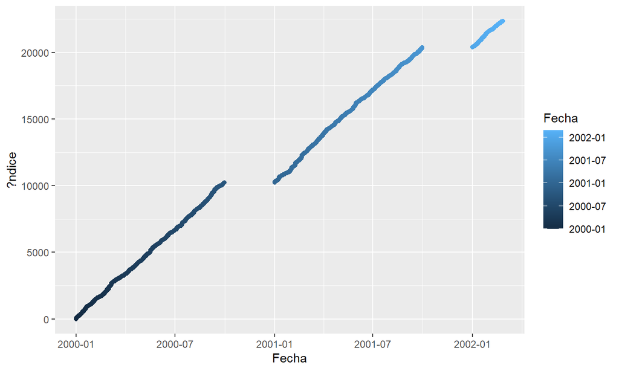

```r
plot1 <- ggplot(online, aes(Fecha, seq_along(Fecha))) +
  geom_point(aes(color = Fecha)) + ylab("?ndice"); plot1
```

Observamos que se produjeron dos paradas en la ventas, que se reiniciaron en *2001-01* y *2002-01*

## Visualiza con distintos gráficos el *dataset*: valores distintos de cada columna (II)

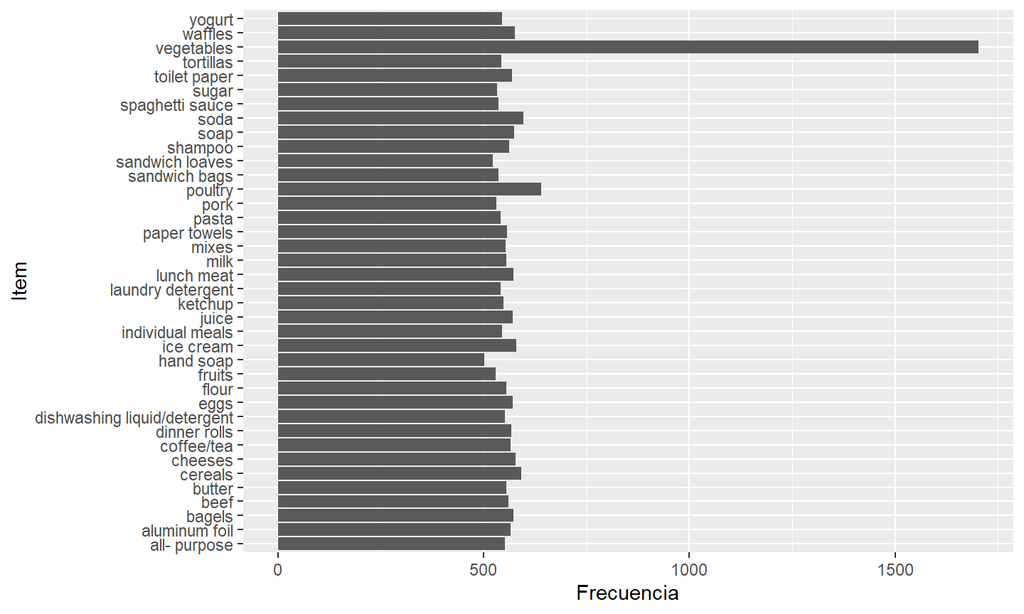

```r
plot2 <- ggplot(online, aes(ProductoComprado)) +
  geom_bar() +
  xlab("Item") + ylab("Frecuencia") +
  coord_flip(); plot2
```

## Visualiza con distintos gr?ficos el *dataset*: enfrenta unas variables contra otras para buscar patrones (I)

Puede ser interesante conocer las ventas según el mes o el año. Para ello, debemos manipular el *dataset* original.

Añadimos nuevas columnas, *Mes* y *Year*:

```r
online2 <- online %>%
  mutate(Mes = months(Fecha)) %>%
  mutate(Year = as.numeric(format(Fecha,'%Y')))
```

Ahora podemos agrupar por a?o y visualizar:

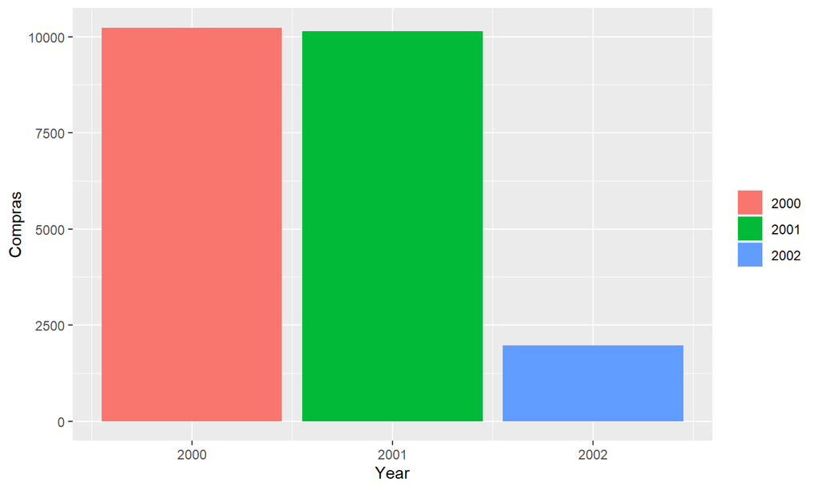

```r
plot3 <- ggplot(online2, aes(Year, fill = as.factor(Year))) +
  geom_bar() +
  ylab("Compras") +
  guides(fill=guide_legend(title=NULL))

plot3
```

## Visualiza con distintos gráficos el *dataset*: enfrenta unas variables contra otras para buscar patrones (II)

También sería útil visualizar el n?mero de compras en cada mes por año.

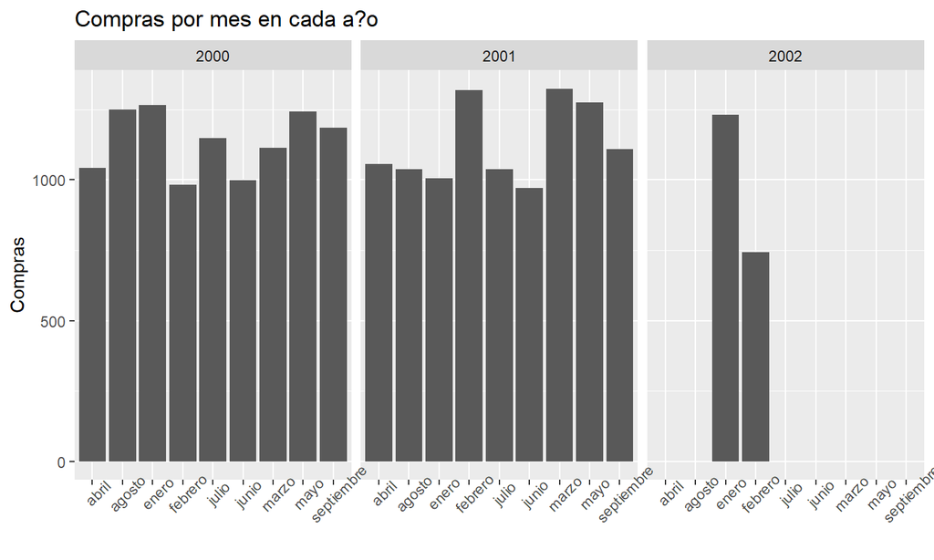

```r
plot4 <- ggplot(online2, aes(Mes)) +
  geom_bar() +
  facet_wrap(~ Year) +
  theme(axis.text.x = element_text(angle = 45)) +
  labs(title = "Compras por mes en cada a?o", x = NULL, y = "Compras")

plot4
```

## Usa `split` para construir a partir del *dataset* una lista con nombre *lista.compra.usuarios* en la que cada elemento de la lista es cada comprador junto con todos los productos que ha comprado

Tras dividir por comprador, uso `lapply()` para quedarme con los productos.

```r
lista.compra.usuarios <- split(online, online$IDcomprador)
lista.compra.usuarios <- lapply(lista.compra.usuarios,
                                function(x) x$ProductoComprado)
lista.compra.usuarios[1]
```

```
## $`1`
##  [1] "yogurt"            "pork"              "sandwich bags"
##  [4] "lunch meat"        "all- purpose"      "flour"
##  [7] "soda"              "butter"            "vegetables"
## [10] "beef"              "aluminum foil"     "all- purpose"
## [13] "dinner rolls"      "shampoo"           "all- purpose"
## [16] "mixes"             "soap"              "laundry detergent"
## [19] "ice cream"         "dinner rolls"
```

## Hacer `summary` y contar usuarios de *lista.compra.usuarios*

```r
head(summary(lista.compra.usuarios))
```

```
##   Length Class  Mode
## 1 20     -none- character
## 2 23     -none- character
## 3 31     -none- character
## 4  6     -none- character
## 5 27     -none- character
## 6 28     -none- character
```

```r
length(lista.compra.usuarios)
```

```
## [1] 1139
```

## Eliminar duplicados, contar cuántos usuarios hay en la lista después de eliminar duplicados en la *lista.compra.usuarios* y convertir a tipo de datos transacciones

- Podemos usar `unique()` para quitar los duplicados, aunque no hay:

```r
length(lista.compra.usuarios) == length(unique(lista.compra.usuarios))
```

```
## [1] TRUE
```

- Convertimos a tipo *transacciones*:

```r
Tlista.compra.usuarios <- as(lista.compra.usuarios, "transactions")
```

## Hacer `inspect` de los dos primeros valores

```r
inspect(Tlista.compra.usuarios[1:2])
```

```
##     items                          transactionID
## [1] {all- purpose,
##      aluminum foil,
##      beef,
##      butter,
##      dinner rolls,
##      flour,
##      ice cream,
##      laundry detergent,
##      lunch meat,
##      mixes,
##      pork,
##      sandwich bags,
##      shampoo,
##      soap,
##      soda,
##      vegetables,
##      yogurt}                                   1
## [2] {aluminum foil,
##      cereals,
##      cheeses,
##      dishwashing liquid/detergent,
##      hand soap,
##      individual meals,
##      laundry detergent,
##      milk,
##      mixes,
##      sandwich bags,
##      shampoo,
##      toilet paper,
##      tortillas,
##      vegetables,
##      waffles,
##      yogurt}                                   2
```

## Buscar ayuda de `itemFrequencyPlot` para visualizar las \(20\) transacciones más frecuentes

La clave está en el par?metro *topN*:

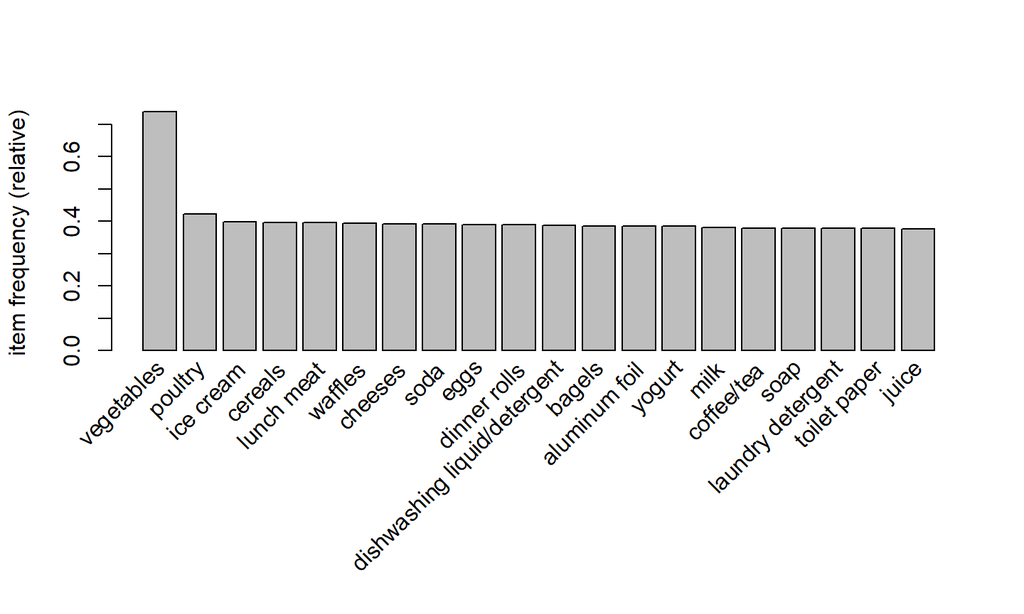

```r
itemFrequencyPlot(Tlista.compra.usuarios, topN = 20)
```

## Generar las reglas de asociaci?n con \(80\)% de confianza y \(15\)% de soporte

Usamos la función `apriori()` para generar las reglas:

```r
reglas <- apriori(Tlista.compra.usuarios,
                  parameter = list(supp = 0.15, conf = 0.8))
```

```
## Apriori
##
## Parameter specification:
##  confidence minval smax arem  aval originalSupport maxtime support minlen
##         0.8    0.1    1 none FALSE            TRUE       5    0.15      1
##  maxlen target  ext
##      10  rules TRUE
##
## Algorithmic control:
##  filter tree heap memopt load sort verbose
##     0.1 TRUE TRUE  FALSE TRUE    2    TRUE
##
## Absolute minimum support count: 170
##
## set item appearances ...[0 item(s)] done [0.00s].
## set transactions ...[38 item(s), 1139 transaction(s)] done [0.00s].
## sorting and recoding items ... [38 item(s)] done [0.00s].
## creating transaction tree ... done [0.00s].
## checking subsets of size 1 2 3 done [0.00s].
## writing ... [22 rule(s)] done [0.00s].
## creating S4 object  ... done [0.00s].
```

## Ver las reglas generadas y ordenalas por *lift*. Guarda el resultado en una variable nueva (I)

```r
reglas.por.lift <- sort(reglas, by = "lift")
```

```r
inspect(reglas.por.lift)
```

```
##      lhs                                       rhs          support
## [1]  {eggs,yogurt}                          => {vegetables} 0.1571554
## [2]  {dinner rolls,eggs}                    => {vegetables} 0.1562774
## [3]  {dishwashing liquid/detergent,eggs}    => {vegetables} 0.1536435
## [4]  {cereals,laundry detergent}            => {vegetables} 0.1510097
## [5]  {cheeses,eggs}                         => {vegetables} 0.1501317
## [6]  {eggs,poultry}                         => {vegetables} 0.1553995
## [7]  {cereals,eggs}                         => {vegetables} 0.1510097
## [8]  {aluminum foil,yogurt}                 => {vegetables} 0.1527656
## [9]  {mixes,poultry}                        => {vegetables} 0.1562774
## [10] {dishwashing liquid/detergent,poultry} => {vegetables} 0.1597893
## [11] {lunch meat,waffles}                   => {vegetables} 0.1571554
## [12] {lunch meat,poultry}                   => {vegetables} 0.1580334
## [13] {poultry,sugar}                        => {vegetables} 0.1518876
## [14] {eggs,soda}                            => {vegetables} 0.1580334
```

[output cut: 31 more lines]

## Elimina todas las reglas redundantes. Calcula el % de reglas redundantes que había

- Eliminamos las reglas redundantes:

```r
reglas.no.redun.lift <- reglas.por.lift[!is.redundant(reglas.por.lift)]
```

- Aunque no hay reglas redundantes, el % de reglas redundantes puede calcularse:

\(porcentaje = \frac{reglas.redundantes}{total.reglas} * 100\)

donde

\(reglas.redundantes =\) `length(reglas.por.lift)` - `lenght(reglas.no.redun.lift)`

y \(total.reglas =\) `length(reglas.por.lift)`

## Dibuja las reglas ordenadas y no redundantes usando paquete *arulesViz* (I)

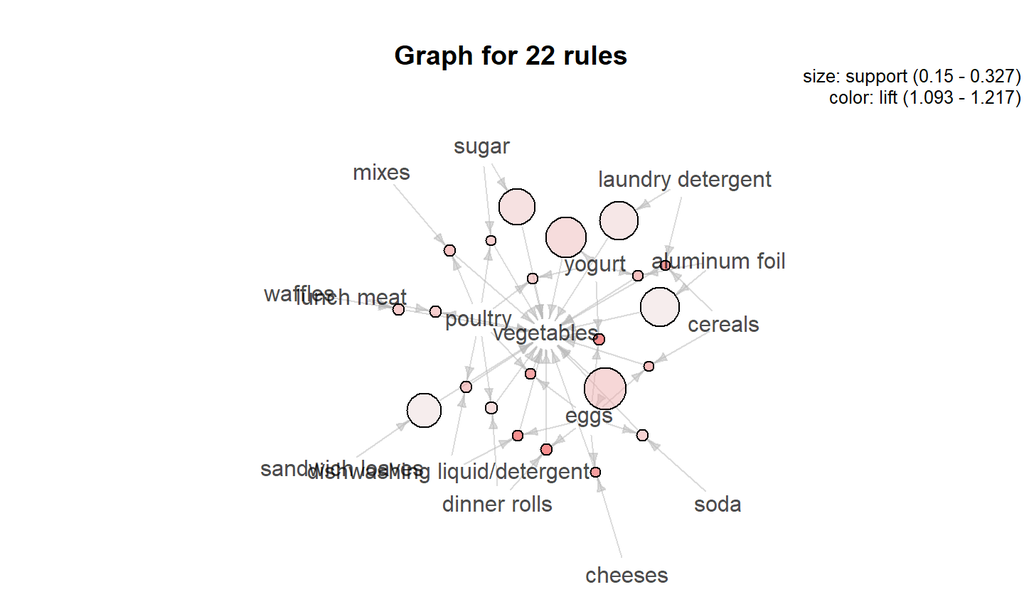

```r
library(arulesViz)
plot(reglas.no.redun.lift, method = "graph")
```

## Dibuja las reglas ordenadas y no redundantes usando paquete *arulesViz* (II)

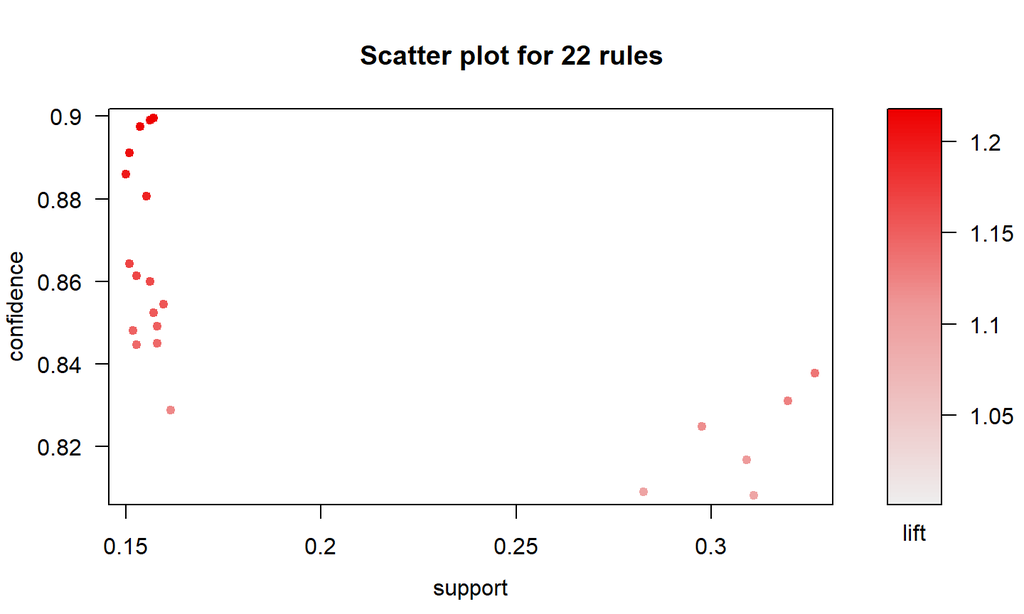

```r
plot(reglas.no.redun.lift)
```

## Aplicar la noción de *afinidad* introducida en clase

Usamos la función `affinity()` para calcular una matriz de afinidad entre los *items*. Sólo se muestra una submatriz de \(9\times5\)

```r
affinity(Tlista.compra.usuarios)[1:9, 1:5]
```

```
##               all- purpose aluminum foil    bagels      beef    butter
## all- purpose     0.0000000     0.2609329 0.2460432 0.2394775 0.2477876
## aluminum foil    0.2609329     0.0000000 0.2802920 0.2664714 0.2438316
## bagels           0.2460432     0.2802920 0.0000000 0.2587209 0.2525547
## beef             0.2394775     0.2664714 0.2587209 0.0000000 0.2085714
## butter           0.2477876     0.2438316 0.2525547 0.2085714 0.0000000
## cereals          0.2436261     0.2700000 0.2624113 0.2798834 0.2446352
## cheeses          0.2403983     0.2797101 0.2756133 0.2637681 0.2668622
## coffee/tea       0.2413295     0.2626996 0.2478510 0.2306590 0.2369186
## dinner rolls     0.2554113     0.2731214 0.2510638 0.2536023 0.2510885
```

## Investigar algún otro paquete *R* relacionado con reglas de asociación. Explicar su uso con un *dataset* y ejemplos (I)

El paquete *RWeka* es una interfaz de *R* para *Weka*.

*Weka* es una colección de algoritmos de *machine learning* para tareas *data mining*.

Está escrito en *Java* y tiene herramientas para preprocesar datos, clasficación, regresión, *clustering*, **reglas de asociación** y visualización.

Se puede encontrar más información en:  
https://cran.r-project.org/web/packages/RWeka/RWeka.pdf  
https://rdrr.io/cran/RWeka/man/Weka_associators.html

## Investigar algún otro paquete *R* relacionado con reglas de asociación. Explicar su uso con un *dataset* y ejemplos (II)

- Cargamos el *dataset* mediante la función `read.arff()`: